# Final BDA 503 - Fall 2019

Tugce AYDIN

12/21/2019

## Part I: Short and Simple

### Question 1

```
1. What is your opinion about the AI hype? Do you think that, in 10 years, AI will solve many critical
problems? What about the required human capital to build all the AI? If we consider a sufficient level
a 100 what would be our level as Turkey / World? Why do you think so? (Give a number for both
Turkey and the World and defend your scoring)
```

### Answer

Artificial intelligence will shape our living standards, the way we live and offer us a new culture of life. I don’t believe that this technology will be end of world, but it can manipulate our lives! Like a Cambridge Analytica scandal.

Ai can be solve the many problems on many sector.I think It will be effect all industry in the next 10 year.Such as in healty sector,AI can get ahead of the doctors in the diagnosis of various diseases. AI is replacing to Call centers.Human support to call centers can be very diminished. So While artificial intelligence reduces the need for manpower in many professions, Manpower in artificial intelligence field will increase exponentially.The resources allocated by the companies to Artificial Intelligence will continue to increase over the years.

We experience the Artificial Intelligence on the voice response system in call centers of institutions such as banks and telecommunications in Turkey. By the way Institutions use the AI for predictive analytics.But When we look applications of AI in the world ,such as self driving vehicles,AI Translation earbuds vs. We see that they are precursor ,but we can say Turkey is strict follower of AI especially in private sector.So While I can evaluate with 65 points out of 100 for Turkey , I can give 85 points to the World .

### Question 2

```
2. What is your exploratory data analysis workflow? Suppose you are given a data set and a research
question. Where do you start? How do you proceed? For instance, you are given the task to distribute
funds from donations to public welfare projects in a wide range of subjects (e.g. education, gender
equality, poverty, job creation, healthcare) with the objective of maximum positive impact on the society
in general. Assume you have almost all the data you require. How do you measure impact? How do
you form performance measures? What makes you think you find an interesting angle?
Would you present an argument for a policy that you are more inclined to (e.g. suppose you are more
inclined to allocate budget to fix gender inequality than affordable healthcare) or would you just present
what data says? In other words, would the (honest) title of your presentation be “Gender Inequality -
The Most Important Social Problem Backed by Data” or “Pain Points in Our Society and Optimal
Budget Allocation”?
```

### Answer

First of all, I generate questions about the dataset. Then I make data cleaning and look for answers to my questions by visualizing, transforming and modeling my data.According to what I learned from my analysis, I renew my questions or continue to examine them by producing new questions.

If I had distrubuted funds from donations to public welfare projects ,I would try to find relation between subjects and their positive impact on the society. When I model the data set ,I seperate according to subjects.First of all, I prefer to examine subjects’ effects one by one. Then I try to identify areas that affect one other.Such as When You support job creation, You can make positive impact on poverty also.

Probably My first questions will be based on measuring the points that I already know about the society in where I live.If the answers that I received different from what I expected, I prefer to distribute funds based on the data.

### Question 3

```
3. If you had to plot a single graph using the diamonds data what would it be? Why? Make your argument,
actually code the plot and provide the output. (You can find detailed info about the movies data set in
its help file. Use ?diamonds, after you load ggplot2 package.)
```

### Answer

I prefer to choose a chart that highlights the attributes that affect the price.Because The price shows the value of the diamond, and it is important to know what increases it.

```r
library(ggplot2)
dplyr::glimpse(diamonds)
```

```
## Observations: 53,940
## Variables: 10
## $ carat   <dbl> 0.23, 0.21, 0.23, 0.29, 0.31, 0.24, 0.24, 0.26, 0.22, ...
## $ cut     <ord> Ideal, Premium, Good, Premium, Good, Very Good, Very G...
## $ color   <ord> E, E, E, I, J, J, I, H, E, H, J, J, F, J, E, E, I, J, ...
## $ clarity <ord> SI2, SI1, VS1, VS2, SI2, VVS2, VVS1, SI1, VS2, VS1, SI...
## $ depth   <dbl> 61.5, 59.8, 56.9, 62.4, 63.3, 62.8, 62.3, 61.9, 65.1, ...
## $ table   <dbl> 55, 61, 65, 58, 58, 57, 57, 55, 61, 61, 55, 56, 61, 54...
## $ price   <int> 326, 326, 327, 334, 335, 336, 336, 337, 337, 338, 339,...
## $ x       <dbl> 3.95, 3.89, 4.05, 4.20, 4.34, 3.94, 3.95, 4.07, 3.87, ...
## $ y       <dbl> 3.98, 3.84, 4.07, 4.23, 4.35, 3.96, 3.98, 4.11, 3.78, ...
## $ z       <dbl> 2.43, 2.31, 2.31, 2.63, 2.75, 2.48, 2.47, 2.53, 2.49, ...
```

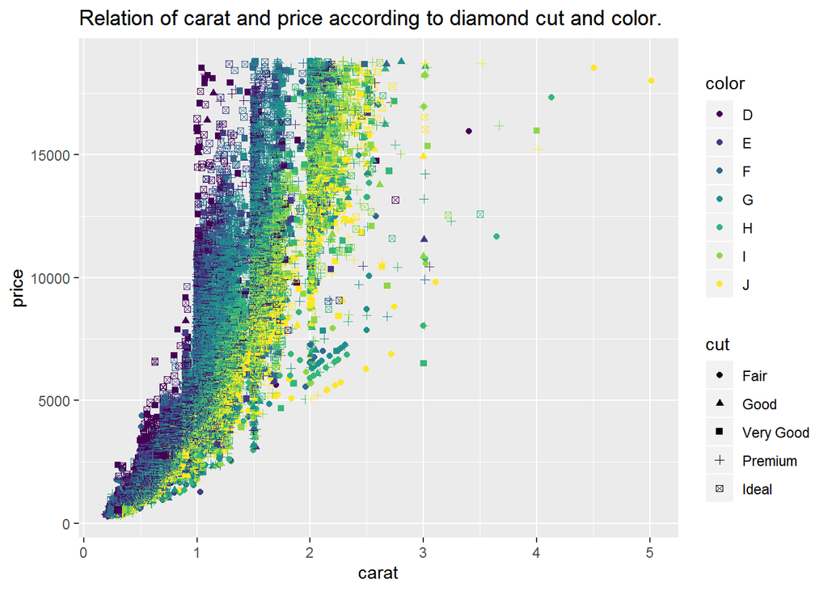

```r
# Relation of carat and price according to diamond cut and color

ggplot(diamonds,aes(x=carat,y=price))+geom_jitter(aes(color=color,shape=cut))+
labs(title="Relation of carat and price according to diamond cut and color.")
```

## Part II: Extending Your Group Project

House Sales to Foreigners has been the one part of our project. We have reported total house sales to foreigners by year and season. In addition, we presented sales figures with the province detail. I will add more detail to this part and I will analyze sales figures by months for 2013 to 2019.

### Comparing home sales to foreigners by years and months.

```r
# Reading csv from the url
file_url<- paste('https://github.com/pjournal/mef03g-road-runner/blob/master/TUIK-DATA/House_Sales_Foreigners.csv?raw=true', sep='')


raw_data <- read.csv(file_url,sep=',',header=T)
Tuik_Foreigners <- raw_data %>% mutate_if(is.numeric,funs(ifelse(is.na(.),0,.)))
```

```r
# Forming the data set for analysis

df_January   <- Tuik_Foreigners %>% group_by(Year) %>% summarise(total_sum=sum(January))%>%
              mutate(Month='January',rank=1)%>%select(Year,Month,total_sum,rank)
df_February <- Tuik_Foreigners %>% group_by(Year) %>% summarise(total_sum=sum(February))        %>%
              mutate(Month='February',rank=2)%>%select(Year,Month,total_sum,rank)
df_March   <- Tuik_Foreigners %>% group_by(Year) %>%
              summarise(total_sum=sum(March))%>%mutate(Month='March',rank=3)%>%select(Year,Month,total_sum,rank)
df_April   <- Tuik_Foreigners %>% group_by(Year) %>%
              summarise(total_sum=sum(March))%>%mutate(Month='April',rank=4)%>%select(Year,Month,total_sum,rank)
df_May     <- Tuik_Foreigners %>% group_by(Year) %>%
              summarise(total_sum=sum(May))%>%mutate(Month='May',rank=5)%>%select(Year,Month,total_sum,rank)
df_June    <- Tuik_Foreigners %>% group_by(Year) %>%
              summarise(total_sum=sum(June))%>%mutate(Month='June',rank=6)%>%select(Year,Month,total_sum,rank)
df_July    <- Tuik_Foreigners %>% group_by(Year) %>%
              summarise(total_sum=sum(July))%>%mutate(Month='July',rank=7)%>%select(Year,Month,total_sum,rank)
df_August  <- Tuik_Foreigners %>% group_by(Year) %>% summarise(total_sum=sum(August))%>%
              mutate(Month='August',rank=8) %>%select(Year,Month,total_sum,rank)
df_September <- Tuik_Foreigners %>% group_by(Year) %>% summarise(total_sum=sum(September))%>%
              mutate(Month='September',rank=9)%>%select(Year,Month,total_sum,rank)
df_October  <- Tuik_Foreigners %>% group_by(Year) %>% summarise(total_sum=sum(October))%>%
              mutate(Month='October',rank=10)%>%select(Year,Month,total_sum,rank)
df_November <- Tuik_Foreigners %>% group_by(Year) %>% summarise(total_sum=sum(November))%>%
              mutate(Month='November',rank=11)%>%select(Year,Month,total_sum,rank)
df_December <- Tuik_Foreigners %>% group_by(Year) %>% summarise(total_sum=sum(December))%>%
              mutate(Month='December',rank=12)%>%select(Year,Month,total_sum,rank)
```

```r
# Union all

df_sales_by_month <- union(union(union(union(union(union(union(union(union(union(union(df_January,df_February),df_March),df_April),df_May),df_June),df_July),df_August),df_September),df_October),df_November),df_December)
```

```r
#Data set for visualization

df_sales_by_month <-df_sales_by_month%>% group_by(Year,Month,rank) %>% summarise(total_sum=sum(total_sum)) %>% select(Year,Month,total_sum,rank) %>%arrange(rank)

head(df_sales_by_month, 10)
```

```
## # A tibble: 10 x 4
## # Groups:   Year, Month [10]
##     Year Month    total_sum  rank
##    <int> <chr>        <dbl> <dbl>
##  1  2013 January        888     1
##  2  2014 January       1207     1
##  3  2015 January       1289     1
##  4  2016 January       1462     1
##  5  2017 January       1386     1
##  6  2018 January       1742     1
##  7  2019 January       3168     1
##  8  2013 February       716     2
##  9  2014 February      1071     2
## 10  2015 February      1369     2
```

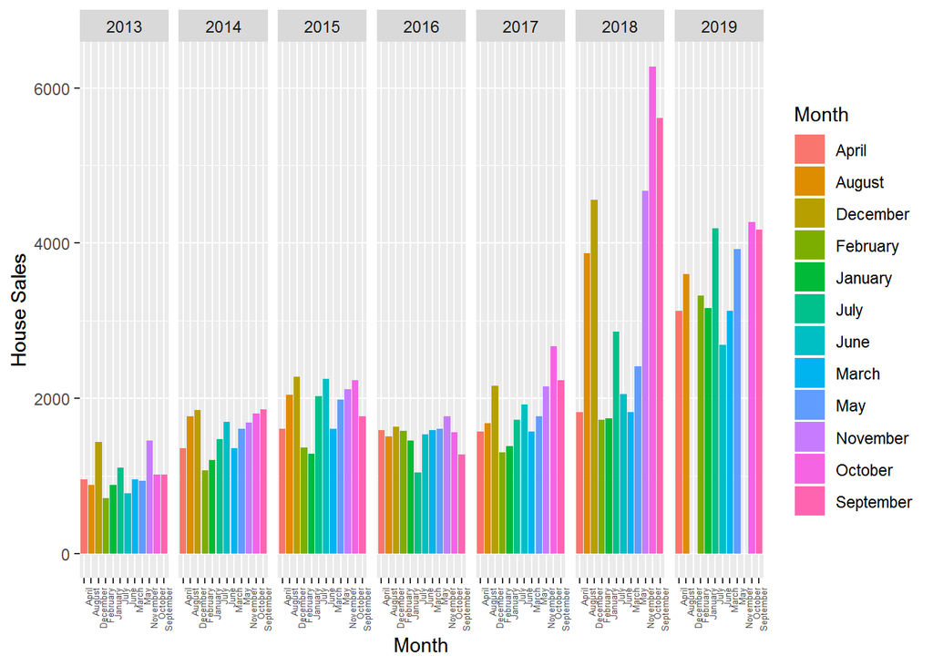

### Conclusion

**2019 November and December data is missing.TUIK haven’t published those data yet.

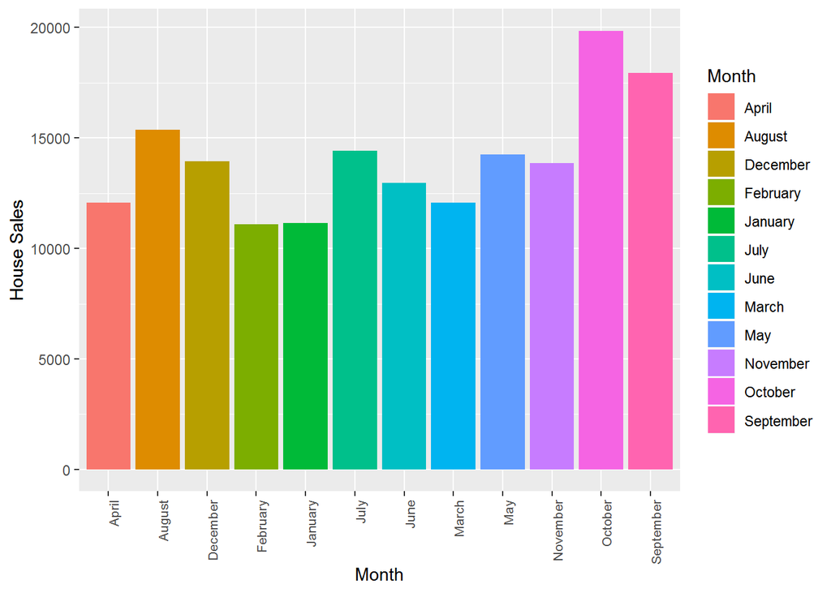

## Part III: Welcome to Real Life

In this part I analyze Organing Farming Data Set that has been published by Republic Of Turkey Ministry Of Agriculture.I will examine Organic Agriculture Data between 2014-2018 by province, agri product and Quantity pf Production. [Data Link](https://www.tarimorman.gov.tr/Konular/Bitkisel-Uretim/Organik-Tarim/Istatistikler)

### Data Cleaning

Extracting data set and Reformatting data.

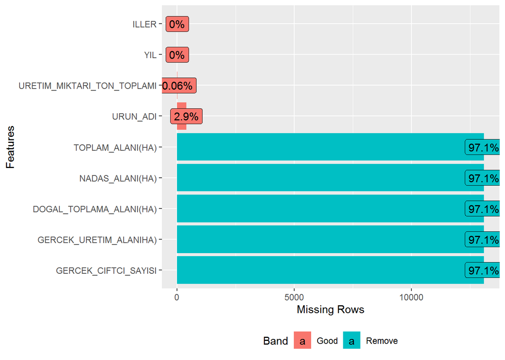

Added 0 value to numeric columns for rows that have missing value. Null values for “URUN_ADI” is coming for cumulative total rows. So we don’t need any arrangement. It is expected value for those rows.

```r
#Reformatting  data
all_organic_agriculture <-
    all_organic_agriculture %>%mutate_if(is.numeric,funs(ifelse(is.na(.),0,.)))
# NA analyzing for URUN_ADI column
na_URUN_ADI <-all_organic_agriculture%>%filter(is.na(URUN_ADI))
head(na_URUN_ADI,3)
```

```
## # A tibble: 3 x 9
##     YIL ILLER URUN_ADI GERCEK_CIFTCI_S~ `GERCEK_URETIM_~ `DOGAL_TOPLAMA_~
##   <dbl> <chr> <chr>               <dbl>            <dbl>            <dbl>
## 1  2014 TOPL~ <NA>                  170             779.             1490
## 2  2014 TOPL~ <NA>                   94             447.                0
## 3  2014 TOPL~ <NA>                  248            1059.                0
## # ... with 3 more variables: `NADAS_ALANI(HA)` <dbl>,
## #   `TOPLAM_ALANI(HA)` <dbl>, URETIM_MIKTARI_TON_TOPLAMI <dbl>
```

### Variables

Data period is Annual. Column names and explanations are below

1. YIL : Year
2. ILLER: Provice
3. URUN_ADI: Product Name
4. GERCEK_CIFTCI_SAYISI: Number Of Real Farmers
5. GERCEK_URETIM_ALANIHA: Real Production Area
6. DOGAL_TOPLAMA_ALANI(HA): Natural Collection Area
7. NADAS_ALANI(HA): Fallow Area
8. TOPLAM_ALANI(HA): Total Area
9. URETIM_MIKTARI_TON_TOPLAMI: Total of Production Quantity(tons)

```r
str(all_organic_agriculture)
```

```
## Classes 'tbl_df', 'tbl' and 'data.frame':    13493 obs. of  9 variables:
##  $ YIL                       : num  2014 2014 2014 2014 2014 ...
##  $ ILLER                     : chr  "ADANA" "ADANA" "ADANA" "ADANA" ...
##  $ URUN_ADI                  : chr  "ACUR" "AHUDUDU" "ALIC(DOGADAN TOPLAMA)" "ARMUT" ...
##  $ GERCEK_CIFTCI_SAYISI      : num  0 0 0 0 0 0 0 0 0 0 ...
##  $ GERCEK_URETIM_ALANIHA)    : num  0 0 0 0 0 0 0 0 0 0 ...
##  $ DOGAL_TOPLAMA_ALANI(HA)   : num  0 0 0 0 0 0 0 0 0 0 ...
##  $ NADAS_ALANI(HA)           : num  0 0 0 0 0 0 0 0 0 0 ...
##  $ TOPLAM_ALANI(HA)          : num  0 0 0 0 0 0 0 0 0 0 ...
##  $ URETIM_MIKTARI_TON_TOPLAMI: num  0.2 0.1 40 0.08 16.48 ...
```

### Visualization

There is 489 organic agri product 2014 to 2018.

```r
df_full <-all_organic_agriculture%>% group_by(URUN_ADI) %>%filter(!is.na(URUN_ADI))%>%select( URUN_ADI )%>% distinct()
NROW(na.omit(df_full))
```

```
## [1] 489
```

The 10 Most Produced Organic Product in Turkey

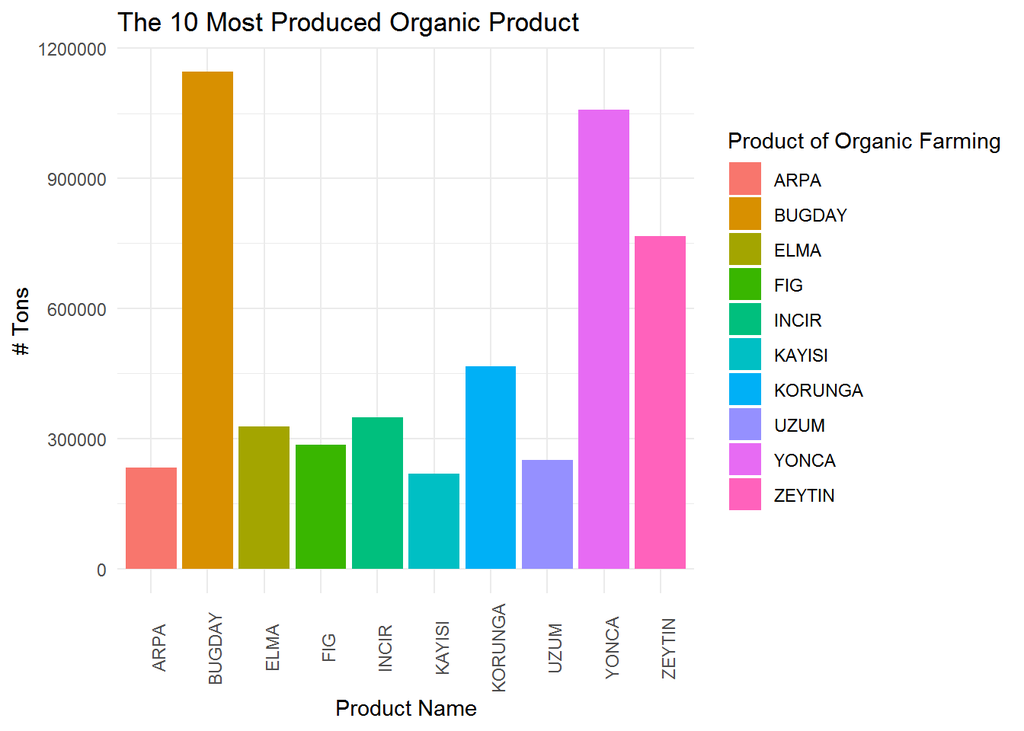

```r
df_Quantity_by_product_name <-all_organic_agriculture%>% group_by(URUN_ADI) %>%filter(!is.na(URUN_ADI))%>%summarise(Total_Product_Quantity=sum(URETIM_MIKTARI_TON_TOPLAMI))%>%select( URUN_ADI ,Total_Product_Quantity )%>% arrange(desc(Total_Product_Quantity))%>%mutate( rank =row_number(),vars_group = 'Total_Product_Quantity' )%>% filter(rank<11)%>%select(PRODUCT_NAME=URUN_ADI,Total_Product_Quantity,rank)

ggplot(df_Quantity_by_product_name, aes(x=PRODUCT_NAME, y=Total_Product_Quantity, fill=PRODUCT_NAME))+
  geom_bar(stat="identity")+
  theme_minimal()+
  labs(x="Product Name",y="# Tons",title="The 10 Most Produced Organic Product",fill="Product of Organic Farming")+
  theme(axis.text.x = element_text(angle=90))
```

When We look at the overall picture in Turkey, we can see the intensity of quantity of production by provinces on the map.

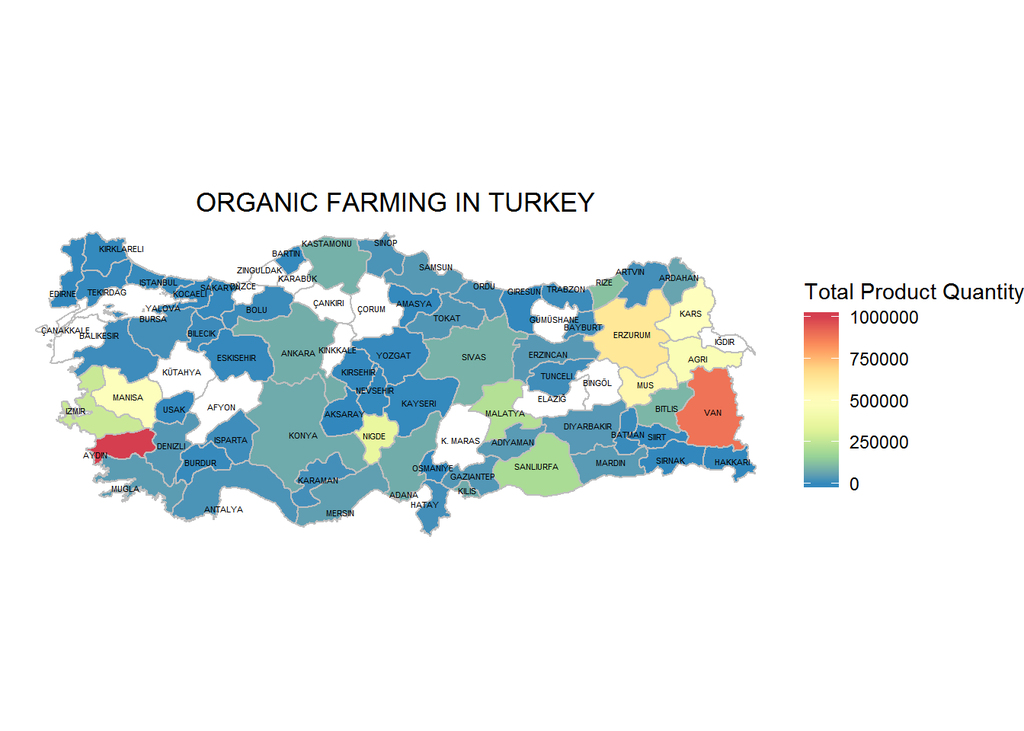

```r
ggplot(final_map) +
  geom_polygon( aes(x = long, y = lat, group = group, fill = Total_Product_Quantity),
                color = "grey") +
    geom_text(aes(x = long, y = lat,label = Province), data = Province_map_data,  size = 1.5, hjust = 0.5)+
  coord_map() +
  theme_void() +
  labs(title = "ORGANIC FARMING IN TURKEY") +
  scale_fill_distiller(name = "Total Product Quantity",
                       palette = "Spectral", limits = c(0,1000000), na.value = "White") +
  theme(plot.title = element_text(hjust = 0.5),
        plot.subtitle = element_text(hjust = 0.5))
```